# Assignment 1 AMS

Ranieri Martin 967158

November 2021

## Part A

Consider the following function:

```r
F = function(x) (1 - (1/exp((x^2)/8)))
```

### Check whether it is a proper CDF using the limit properties only.

```r
x = ysym("x")
lim(F(x), x, +Inf)
```

```
## y: 1
```

Yes, it goes to 1

### Plot it

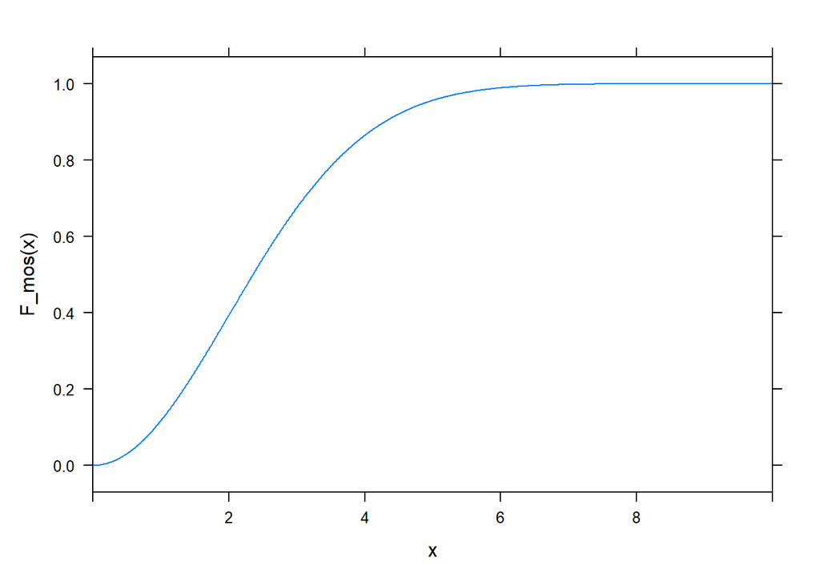

```r
F_mos = makeFun(F(x) ~ x)
plotFun(F_mos(x) ~ x, xlim = c(0, 10) )
```

### Plot its density for X > 0

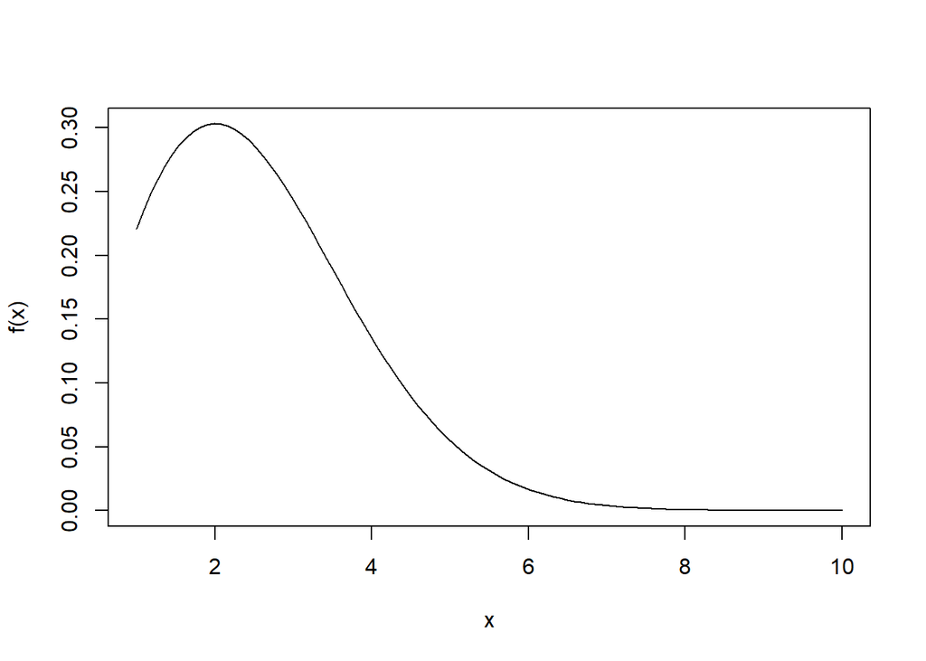

```r
f = function(x) {}
body(f) = D(body(F), 'x')
curve(f, 1, 10, ylab = "f(x)")
```

### Compute P(0 < X ≤ 2.3)

```r
F(2.3) - F(0)
```

```
## [1] 0.4837943
```

### Compute E(X)

As we know E(X) = INTEGER(1 - CDF(X))

```r
M = antiD((1-F(x)) ~ x)
mu = M(+Inf) - M(0)
mu
```

```
## [1] 2.506628
```

### Compute VAR(X)

```r
MM = antiD((x*f(x)*(x)) ~ x)
ex2 = MM(infinite) - MM(0)
ex2 - (mu*mu)
```

```
## [1] 1.716815
```

### Compute the median

```r
F_inv = inverse(F, lower=0, upper=infinite)
F_inv(0.5)
```

```
## [1] 2.354826
```

## Part B

```r
df = read.csv(file = 'CustomerCare.csv')
dt = df[c('Education','Rating_price','Rating_quality')]
```

Consider the CustomerCare.csv dataset on rating about a new product (columns Rating_price and Rating_quality). After considering the variable Education as group variable:

### Perform a MANOVA test to determine if there are differences in the mean vectors ofthe ratings in the education level groups

```r
# test
result = manova(cbind(Rating_price, Rating_quality) ~ Education, data = dt)
summary(result)
```

```
##            Df    Pillai approx F num Df den Df Pr(>F)
## Education   1 0.0021162  0.31492      2    297 0.7301
## Residuals 298
```

We cannot reject the null hypothesis, some extra aside analysis are performed below

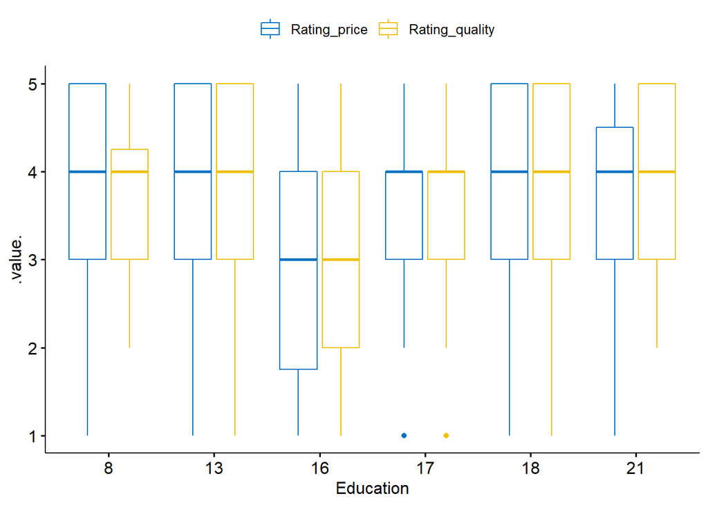

```r
# box plor
ggboxplot(dt,
    x = "Education",
    y = c("Rating_price", "Rating_quality"),
    merge = TRUE, palette = "jco")
```

- independent?

```r
tb = table(dt$Rating_price, dt$Rating_quality)

# chi square

chisq = chisq.test(tb)
chisq
```

```
##
##  Pearson's Chi-squared test
##
## data:  tb
## X-squared = 379.08, df = 16, p-value < 2.2e-16
```

```r
chisq$p.value
```

```
## [1] 8.72333e-71
```

```r
chisq$observed
```

```
##
##      1  2  3  4  5
##   1  5  7  3  0  1
##   2  2 17  4  1  0
##   3  0  6 46  8  2
##   4  0  5 16 63 14
##   5  0  1  8 22 69
```

```r
# dependency

round(100*chisq$residuals^2/chisq$statistic, 3)
```

```
##
##          1      2      3      4      5
##   1 15.125  3.546  0.079  1.322  0.740
##   2  0.977 18.262  0.200  1.491  1.815
##   3  0.382  0.074 15.006  1.773  3.693
##   4  0.603  1.025  0.879  8.959  1.865
##   5  0.616  2.660  3.208  0.733 14.970
```

```r
# ohter stuff

assocstats(tb)
```

```
##                     X^2 df P(> X^2)
## Likelihood Ratio 299.29 16        0
## Pearson          379.08 16        0
##
## Phi-Coefficient   : NA
## Contingency Coeff.: 0.747
## Cramer's V        : 0.562
```

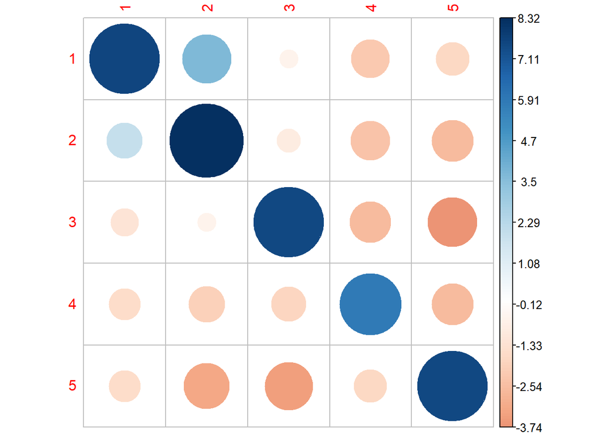

```r
# correlation plot

corrplot(chisq$residuals, is.cor = FALSE)
```

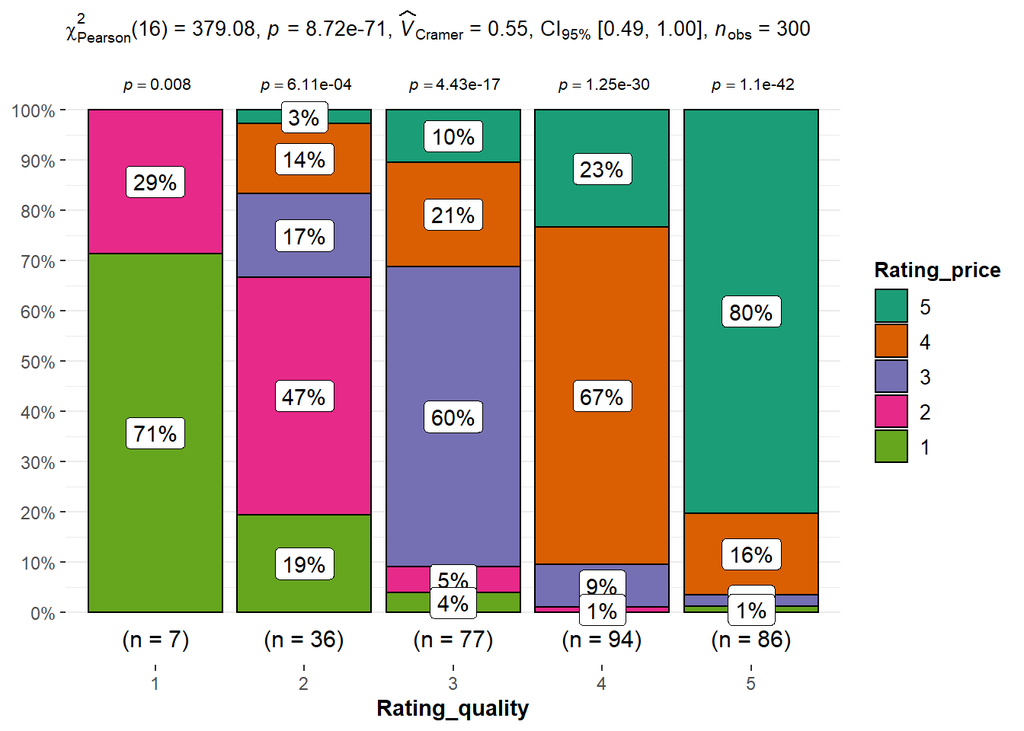

```r
# corr-comp plot

ggbarstats(
  data = dt,
  x = Rating_price,
  y = Rating_quality
) +
  labs(caption = NULL)
```

- well no, except for chi2
- multivariate normality?

```r
mvnormtest::mshapiro.test(t(dt[, 2:3]))
```

```
##
##  Shapiro-Wilk normality test
##
## data:  Z
## W = 0.80925, p-value < 2.2e-16
```

```r
res = heplots::boxM(dt[, 2:3], dt[, 1])
summary(res)
```

```
## Summary for Box's M-test of Equality of Covariance Matrices
##
## Chi-Sq:   32.41102
## df:   15
## p-value: 0.005657
##
## log of Covariance determinants:
##         13         16         17         18         21          8     pooled
## -0.4722714 -0.5867872 -1.7960299 -0.4955803  0.4857875 -0.3503458 -0.4792023
##
## Eigenvalues:
##         13        16         17        18        21         8    pooled
## 1 2.244062 3.0288982 1.94695814 2.0673522 2.0688745 1.6133711 2.1264526
## 2 0.277882 0.1836018 0.08523883 0.2946848 0.7856709 0.4366289 0.2912255
##
## Statistics based on eigenvalues:
##                  13        16         17        18        21         8
## product   0.6235842 0.5561111 0.16595644 0.6092173 1.6254545 0.7044444
## sum       2.5219436 3.2125000 2.03219697 2.3620370 2.8545455 2.0500000
## precision 0.2472634 0.1731085 0.08166356 0.2579203 0.5694268 0.3436314
## max       2.2440616 3.0288982 1.94695814 2.0673522 2.0688745 1.6133711
##              pooled
## product   0.6192772
## sum       2.4176781
## precision 0.2561454
## max       2.1264526
```

- there’s NO homogeneity across groups covariance matrices (null hypotesis rejected)
- multi-collinearity?

```r
cor(dt$Rating_price, dt$Rating_quality)
```

```
## [1] 0.7602854
```

- a weak no (but I’d prefer to say YES)
- linear relationship?
- mmhh idk

### Perform univariate ANOVA tests on each variable

```r
arp <- aov(Rating_price ~ Education, data = dt)
summary(arp)
```

```
##              Df Sum Sq Mean Sq F value Pr(>F)
## Education     1    0.2  0.1786   0.136  0.712
## Residuals   298  390.6  1.3108
```

```r
arq <- aov(Rating_quality ~ Education, data = dt)
summary(arq)
```

```
##              Df Sum Sq Mean Sq F value Pr(>F)
## Education     1    0.6  0.6321   0.545  0.461
## Residuals   298  345.8  1.1606
```

### Compare and comment on results

Nor MANOVA neither disjointly ANOVA suggest that Education groups are meaningful different. Moreover Rating_price and Rating_quality seem not to be independent and uncorrelated, thus MANOVA won’t lead us to reliable results.

## Part C

```r
df = read.csv(file = 'CustomerCare.csv')
dt = df[c("Rating_price","Age")]
```

Consider the CustomerCare.csv dataset on rating about a new product (column Rating_price).

### Implement the classical bootstrap to estimate the 95% confidence intervals of the population Pearson’s correlation coefficient between rating and Age.

```r
N = length(dt[,1])
X = dt$Age
Y = dt$Rating_price
n_iter = 300
```

```r
ci_cor(X, Y, method = "pearson", type = "bootstrap")
```

```
##
##  Two-sided 95% bootstrap confidence interval for the true Pearson
##  correlation coefficient based on 9999 bootstrap replications and the
##  bca method
##
## Sample estimate: 0.04949064
## Confidence interval:
##        2.5%       97.5%
## -0.06609929  0.16204269
```

### Implement an iterative procedure and a package procedure (for example using boot)

#### Iterative procedure

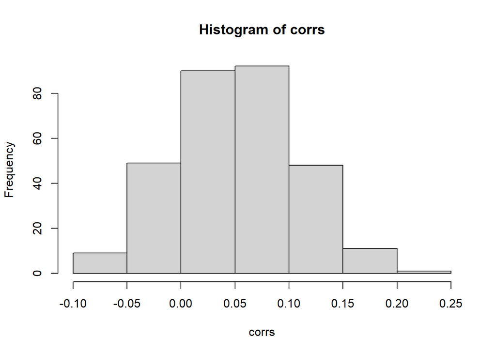

```r
corrs = rep(NULL, n_iter)

for (i in 1:n_iter){
    indexes = as.matrix(sample(1:N, replace=TRUE))
    corrs[i] = cor(X[indexes], Y[indexes], method = "pearson")
}

hist(corrs)
```

```r
sbs = round(ci(corrs, confidence=0.95), 3)
sbs
```

```
##   Estimate   CI lower   CI upper Std. Error
##      0.052      0.045      0.058      0.003
```

#### Package approach

```r
foo = function(data, indexes) {
    return(cor(data[indexes,1],data[indexes,2], method = "pearson"))
}

results = boot(dt, foo, R = n_iter, stype = 'i' )
lmd = boot.ci(boot.out = results, type = "norm", conf=0.95)
pkg = round(c(lmd$t0, lmd$normal[2],lmd$normal[3]), 3)
names(pkg) = c('Estimate',   'CI lower',   'CI upper')
pkg
```

```
## Estimate CI lower CI upper
##    0.049   -0.074    0.169
```

```r
# CI out of Library
ikg = round(ci(results$t, confidence=0.95), 3)
ikg
```

```
##   Estimate   CI lower   CI upper Std. Error
##      0.051      0.044      0.058      0.004
```

### Compare with the Fisher transform method.

#### Fisher z-transform

The sampling distribution of Pearson r is not normally distributed. Fisher developed a transformation now called “Fisher z-transformation” that converts Pearson r to the normally distributed variable z. The formula for the transformation is:
$$z_r = tanh^{-1}(r) = \frac{1}{2}log\left (
\frac{1+r}{1-r}\right )$$

```r
r = cor(X,Y, method = "pearson")
z = FisherZ(r)
se = (1.96)*(1/sqrt(N-3))
fzt = round(FisherZInv(c(z, z - se, z + se)), 3)

names(fzt) = c('Estimate',   'CI lower',   'CI upper')
fzt
```

```
## Estimate CI lower CI upper
##    0.049   -0.064    0.162
```

### Plot the confidence intervals to visually compare the results

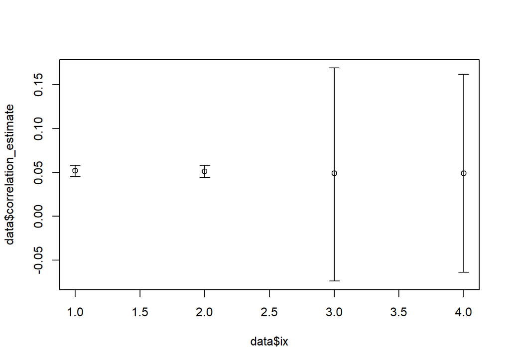

```r
data = data.frame(
    ix = c(1:4),
    correlation_estimate = c(sbs['Estimate'], ikg['Estimate'], pkg['Estimate'], fzt['Estimate']),
    lower = c(sbs['CI lower'], ikg['CI lower'], pkg['CI lower'], fzt['CI lower']),
    upper = c(sbs['CI upper'], ikg['CI upper'], pkg['CI upper'], fzt['CI upper'])
)

plotCI(x = data$ix,
       y = data$correlation_estimate,
       li = data$lower,
       ui = data$upper)
```

Where:

1. Step by Step Bootstrap
2. R Library Bootstrap with manually-computed CI
3. R Library Bootstrap
4. Fisher z-Transform

Basically all methods point out to the same estimates, both Bootstrap package (3) and Fisher z-Transform (4) got an equal confidence interval without looking at the iterative procedure (1), it could be I don’t know how to compute correctly standard errors 🥲.

### Compute the 95% bootstrap confidence interval for Y/X

```r
df = read.csv(file = 'CustomerCare.csv')
dt = df[c('Rating_price','Rating_quality')]
```

```r
foo = function(data, indexes){
  return(sum(data[indexes,1])/sum(data[indexes,2]))
}

res = boot(dt, foo, R = n_iter, stype = "i")
lmd = boot.ci(boot.out = res, type = "norm", conf=0.95)
rat_boo = round(c(lmd$t0, lmd$normal[2], lmd$normal[3]), 3)
names(rat_boo) = c('Estimate',   'CI lower',   'CI upper')
rat_boo
```

```
## Estimate CI lower CI upper
##    1.023    0.999    1.048
```

For the sake of science we’ll give a try also to a Block Bootstrap:

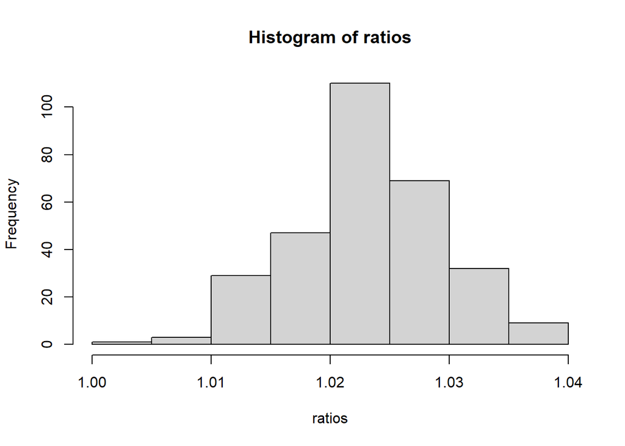

```r
block_len = N*0.8
N_block = 300

ratios = rep(NULL, N_block)

for(i in 1:N_block){
  bunch = sample(dt, block_len)
  ratios[i] = sum(bunch[,1])/sum(bunch[,2])
}

hist(ratios)
```

```r
bkb = round(ci(ratios, confidence=0.95), 3)
bkb
```

```
##   Estimate   CI lower   CI upper Std. Error
##      1.023      1.022      1.024      0.000
```